# Peer Graded Assignment - Practical Machine Learning

2026-05-18

## Overview

Using data from use data from accelerometers on the belt, forearm, arm, and dumbell of 6 participants, this analysis is aimed to predict the “classe” variable from the 20 test cases from the test dataset.

The training data for this project are available here:

https://d396qusza40orc.cloudfront.net/predmachlearn/pml-training.csv

The test data are available here:

https://d396qusza40orc.cloudfront.net/predmachlearn/pml-testing.csv

Dataset: [Human Activity Recognition Dataset](http://web.archive.org/web/20161224072740/http:/groupware.les.inf.puc-rio.br/har)

## Methods

The analysis were done by cleaning irrelevant variable (X, username, timestamps, and window) from both the training and the test data. The cleaned training data were then used to training and modelling algorithms. The training data were splitted into the data used for training the model, and validation, which were used to build Gradient Boosting Machine(GBM) and Random Forest (RF). Accuracy, Kappa Statistics, and Out-of-sample errors were attained from Confusion Matrix. The best model were then used to predict the testing dataset

## Load the data

```r
fileurl_train <- "https://d396qusza40orc.cloudfront.net/predmachlearn/pml-training.csv"
fileurl_test <- "https://d396qusza40orc.cloudfront.net/predmachlearn/pml-testing.csv"

#download the file and verifying the file
if (!file.exists("data")){
    dir.create("data")
}

download.file(fileurl_train, destfile = "./data/train.csv", method = "curl")
download.file(fileurl_test, destfile = "./data/test.csv", method = "curl")

list.files("./data")
```

```
## [1] "test.csv"  "train.csv"
```

```r
dateDownloaded <- date()
dateDownloaded
```

```
## [1] "Mon May 18 21:36:28 2026"
```

## Reading and Cleaning the data

```r
#read the train and test data
traindata <- read.csv("./data/train.csv", sep = ",", header = TRUE)
testdata <- read.csv("./data/test.csv", sep = ",", header = TRUE)

#removing NAs
traindata <- traindata[, colSums(is.na(traindata)) == 0]
testdata <- testdata[, colSums(is.na(testdata)) == 0]

#removing near zero variance
library(caret)
nzv_train <- nearZeroVar(traindata)
nzv_test <- nearZeroVar(testdata)
traindata <- traindata[, -nzv_train]
testdata <- testdata[, -nzv_test]

#removing irrelevant data for model training
variables <- c("X", "user_name", "raw_timestamp_part_1", "raw_timestamp_part_2", "cvtd_timestamp", "num_window")
traindata <- traindata[, !(names(traindata) %in% variables)]
testdata <- testdata[, !(names(testdata) %in% variables)]

#making classe into factor
traindata$classe <- as.factor(traindata$classe)

head(traindata)
```

```
##   roll_belt pitch_belt yaw_belt total_accel_belt gyros_belt_x gyros_belt_y
## 1      1.41       8.07    -94.4                3         0.00         0.00
## 2      1.41       8.07    -94.4                3         0.02         0.00
## 3      1.42       8.07    -94.4                3         0.00         0.00
## 4      1.48       8.05    -94.4                3         0.02         0.00
## 5      1.48       8.07    -94.4                3         0.02         0.02
## 6      1.45       8.06    -94.4                3         0.02         0.00
##   gyros_belt_z accel_belt_x accel_belt_y accel_belt_z magnet_belt_x
## 1        -0.02          -21            4           22            -3
## 2        -0.02          -22            4           22            -7
## 3        -0.02          -20            5           23            -2
## 4        -0.03          -22            3           21            -6
## 5        -0.02          -21            2           24            -6
## 6        -0.02          -21            4           21             0
##   magnet_belt_y magnet_belt_z roll_arm pitch_arm yaw_arm total_accel_arm
```

[output cut: 62 more lines]

```r
head(testdata)
```

```
##   roll_belt pitch_belt yaw_belt total_accel_belt gyros_belt_x gyros_belt_y
## 1    123.00      27.00    -4.75               20        -0.50        -0.02
## 2      1.02       4.87   -88.90                4        -0.06        -0.02
## 3      0.87       1.82   -88.50                5         0.05         0.02
## 4    125.00     -41.60   162.00               17         0.11         0.11
## 5      1.35       3.33   -88.60                3         0.03         0.02
## 6     -5.92       1.59   -87.70                4         0.10         0.05
##   gyros_belt_z accel_belt_x accel_belt_y accel_belt_z magnet_belt_x
## 1        -0.46          -38           69         -179           -13
## 2        -0.07          -13           11           39            43
## 3         0.03            1           -1           49            29
## 4        -0.16           46           45         -156           169
## 5         0.00           -8            4           27            33
## 6        -0.13          -11          -16           38            31
##   magnet_belt_y magnet_belt_z roll_arm pitch_arm yaw_arm total_accel_arm
```

[output cut: 62 more lines]

## Separating training data for training and validation

```r
#creating data partition
set.seed(3233)
inTrain <- createDataPartition(y = traindata$classe, p = 0.75, list = FALSE)
training <- traindata[inTrain,]
validation <- traindata[-inTrain,]
dim(training); dim(validation)
```

```
## [1] 14718    53
```

```
## [1] 4904   53
```

```r
#creating kfolds
folds <- createFolds(y = training$classe, k = 10, list = TRUE, returnTrain = TRUE)
sapply(folds, length)
```

```
## Fold01 Fold02 Fold03 Fold04 Fold05 Fold06 Fold07 Fold08 Fold09 Fold10
##  13246  13245  13246  13247  13246  13245  13245  13247  13248  13247
```

```r
folds <- createFolds(y = validation$classe, k = 10, list = TRUE, returnTrain = TRUE)
sapply(folds, length)
```

```
## Fold01 Fold02 Fold03 Fold04 Fold05 Fold06 Fold07 Fold08 Fold09 Fold10
##   4412   4414   4414   4414   4414   4413   4414   4414   4414   4413
```

## Fitting GBM model

```r
#gbm - boosting
set.seed(3233)
controlgbm <- trainControl(method="cv", 5, allowParallel = TRUE)
gbmmodel <- train(classe~., data = training, method = "gbm", verbose = FALSE, trControl = controlgbm)
gbmmodel
```

```
## Stochastic Gradient Boosting
##
## 14718 samples
##    52 predictor
##     5 classes: 'A', 'B', 'C', 'D', 'E'
##
## No pre-processing
## Resampling: Cross-Validated (5 fold)
## Summary of sample sizes: 11775, 11773, 11775, 11774, 11775
## Resampling results across tuning parameters:
##
##   interaction.depth  n.trees  Accuracy   Kappa
##   1                   50      0.7529570  0.6867109
##   1                  100      0.8185905  0.7704383
##   1                  150      0.8514078  0.8120318
##   2                   50      0.8518151  0.8122690
##   2                  100      0.9062381  0.8813718
##   2                  150      0.9320561  0.9140360
##   3                   50      0.8965217  0.8690143
##   3                  100      0.9421796  0.9268430
##   3                  150      0.9599129  0.9492856
##
## Tuning parameter 'shrinkage' was held constant at a value of 0.1
##
## Tuning parameter 'n.minobsinnode' was held constant at a value of 10
## Accuracy was used to select the optimal model using the largest value.
## The final values used for the model were n.trees = 150, interaction.depth =
##  3, shrinkage = 0.1 and n.minobsinnode = 10.
```

```r
#confusion matrix for validating model
predictgbm <- predict(gbmmodel, validation)
confusionMatrix(validation$classe, predictgbm)
```

```
## Confusion Matrix and Statistics
##
##           Reference
## Prediction    A    B    C    D    E
##          A 1382    9    3    1    0
##          B   36  890   20    1    2
##          C    0   16  832    6    1
##          D    1    2   32  762    7
##          E    7    6    5   22  861
##
## Overall Statistics
##
##                Accuracy : 0.9639
##                  95% CI : (0.9583, 0.969)
##     No Information Rate : 0.2908
##     P-Value [Acc > NIR] : < 2.2e-16
##
##                   Kappa : 0.9543
##
##  Mcnemar's Test P-Value : 1.226e-08
##
## Statistics by Class:
##
##                      Class: A Class: B Class: C Class: D Class: E
## Sensitivity            0.9691   0.9642   0.9327   0.9621   0.9885
## Specificity            0.9963   0.9852   0.9943   0.9898   0.9901
## Pos Pred Value         0.9907   0.9378   0.9731   0.9478   0.9556
## Neg Pred Value         0.9875   0.9917   0.9852   0.9927   0.9975
## Prevalence             0.2908   0.1882   0.1819   0.1615   0.1776
## Detection Rate         0.2818   0.1815   0.1697   0.1554   0.1756
## Detection Prevalence   0.2845   0.1935   0.1743   0.1639   0.1837
## Balanced Accuracy      0.9827   0.9747   0.9635   0.9760   0.9893
```

## Fitting RF model

```r
#rf
set.seed(3233)
controlrf <- trainControl(method="cv", 5, allowParallel = TRUE)
rfmodel <- train(classe~., data = training, method = "rf", trControl = controlrf)
rfmodel
```

```
## Random Forest
##
## 14718 samples
##    52 predictor
##     5 classes: 'A', 'B', 'C', 'D', 'E'
##
## No pre-processing
## Resampling: Cross-Validated (5 fold)
## Summary of sample sizes: 11775, 11773, 11775, 11774, 11775
## Resampling results across tuning parameters:
##
##   mtry  Accuracy   Kappa
##    2    0.9913708  0.9890831
##   27    0.9914389  0.9891695
##   52    0.9874990  0.9841845
##
## Accuracy was used to select the optimal model using the largest value.
## The final value used for the model was mtry = 27.
```

```r
#confusion matrix for validating model
predictrf <- predict(rfmodel, validation)
confusionMatrix(validation$classe, predictrf)
```

```
## Confusion Matrix and Statistics
##
##           Reference
## Prediction    A    B    C    D    E
##          A 1393    1    1    0    0
##          B    6  942    1    0    0
##          C    0    2  851    2    0
##          D    0    0    8  796    0
##          E    0    0    1    5  895
##
## Overall Statistics
##
##                Accuracy : 0.9945
##                  95% CI : (0.992, 0.9964)
##     No Information Rate : 0.2853
##     P-Value [Acc > NIR] : < 2.2e-16
##
##                   Kappa : 0.993
##
##  Mcnemar's Test P-Value : NA
##
## Statistics by Class:
##
##                      Class: A Class: B Class: C Class: D Class: E
## Sensitivity            0.9957   0.9968   0.9872   0.9913   1.0000
## Specificity            0.9994   0.9982   0.9990   0.9980   0.9985
## Pos Pred Value         0.9986   0.9926   0.9953   0.9900   0.9933
## Neg Pred Value         0.9983   0.9992   0.9973   0.9983   1.0000
## Prevalence             0.2853   0.1927   0.1758   0.1637   0.1825
## Detection Rate         0.2841   0.1921   0.1735   0.1623   0.1825
## Detection Prevalence   0.2845   0.1935   0.1743   0.1639   0.1837
## Balanced Accuracy      0.9976   0.9975   0.9931   0.9947   0.9993
```

```r
#out of sample error random forest
matrixgbm <- confusionMatrix(validation$classe, predictgbm)
accuracygbm <- matrixgbm$overall["Accuracy"]
errorgbm <- 1 - as.numeric(accuracygbm)
errorgbm
```

```
## [1] 0.03609299
```

```r
#out of sample error random forest
matrixrf <- confusionMatrix(validation$classe, predictrf)
accuracyrf <- matrixrf$overall["Accuracy"]
errorrf <- 1 - as.numeric(accuracyrf)
errorrf
```

```
## [1] 0.00550571
```

## Comparing model

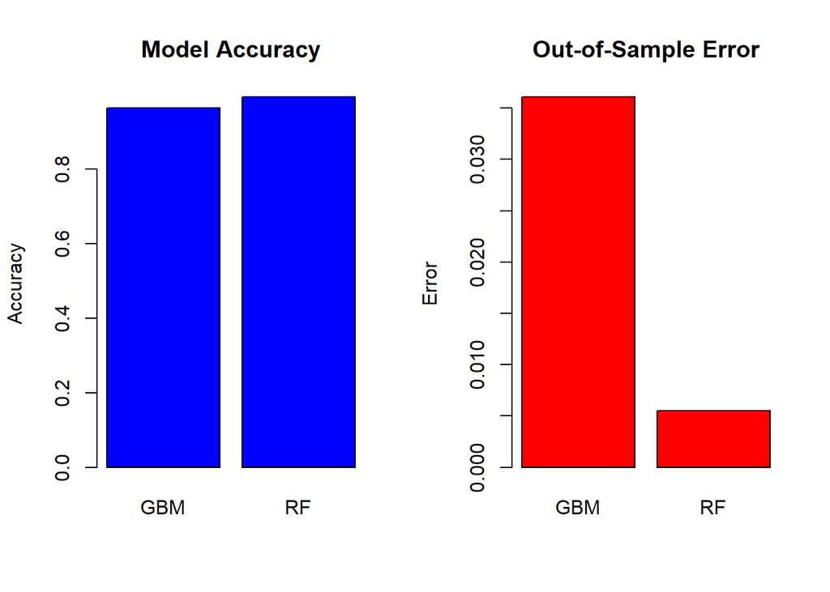

```r
#creating data frame
model_compare <- data.frame(
    Model = c("GBM", "RF"),
    Accuracy = c(as.numeric(accuracygbm), as.numeric(accuracyrf)),
    OutOfSampleError = c(as.numeric(errorgbm), as.numeric(errorrf))
)

#creating bar plot for comparison
par(mfrow = c(1,2))

barplot(model_compare$Accuracy,
        names.arg = model_compare$Model,
        main = "Model Accuracy",
        ylab = "Accuracy",
        col = "blue")

barplot(model_compare$OutOfSampleError,
        names.arg = model_compare$Model,
        main = "Out-of-Sample Error",
        ylab = "Error",
        col = "red")
```

Higher kappa statistic and accuracy showed Random Forest model showed to be a better model than boosted model. Random forest also showed to have lower out of sample error. Hence, **Random Forest were used as the final model for prediction**

## Predicting the testing model

```r
finalmodel <- rfmodel
predicttest <- predict(finalmodel, testdata)
table(predicttest)
```

```
## predicttest
## A B C D E
## 7 8 1 1 3
```